# dplyr

Dayana Moncada

8/30/2017

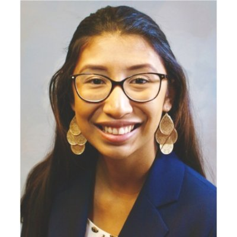

International Student from Honduras. First year graduate student at Mercyhurst University in Data Science. Data Analytics | Political Science & Public Policy Advocacy | Fashion Data Analysis

## Filtering Columns and Rows

When using dplyr, you can filter columns and rows by using select and filter. Let’s look at an example using the Lahman baseball database. We first have to load the Lahman and dplyr packages.

```r
library(Lahman)
library(dplyr)
```

Now, suppose we would like to see the homerun totals for the 1927 New York Yankees. We could run the following code:

```r
Batting%>%
  select(playerID,yearID,teamID,HR)%>%
  filter(teamID=="NYA" & yearID==1927)
```

```
##     playerID yearID teamID HR
## 1  beallwa01   1927    NYA  0
## 2  bengobe01   1927    NYA  0
## 3  collipa01   1927    NYA  7
## 4  combsea01   1927    NYA  6
## 5  duganjo01   1927    NYA  2
## 6  durstce01   1927    NYA  0
## 7  gazelmi01   1927    NYA  0
## 8  gehrilo01   1927    NYA 47
## 9  giardjo01   1927    NYA  0
## 10 grabojo01   1927    NYA  0
## 11  hoytwa01   1927    NYA  0
## 12 koenima01   1927    NYA  3
## 13 lazzeto01   1927    NYA 18
## 14 meusebo01   1927    NYA  8
## 15 moorewi01   1927    NYA  1
## 16 morehra01   1927    NYA  1
## 17 paschbe01   1927    NYA  2
## 18 pennohe01   1927    NYA  0
## 19 pipgrge01   1927    NYA  1
## 20 ruethdu01   1927    NYA  1
## 21  ruthba01   1927    NYA 60
## 22 shawkbo01   1927    NYA  0
## 23 shockur01   1927    NYA  0
## 24 thomamy01   1927    NYA  0
## 25  weraju01   1927    NYA  1
```

```r
Batting%>%
  select(playerID,yearID,teamID,HR,SO)%>%
  filter(HR>=40 & SO<60)
```

```
##     playerID yearID teamID HR SO
## 1  hornsro01   1922    SLN 42 50
## 2  willicy01   1923    PHI 41 57
## 3    ottme01   1929    NY1 42 38
## 4  kleinch01   1930    PHI 40 50
## 5  gehrilo01   1931    NYA 46 56
## 6   ruthba01   1931    NYA 46 51
## 7  gehrilo01   1934    NYA 49 31
## 8  gehrilo01   1936    NYA 49 46
## 9  troskha01   1936    CLE 42 58
## 10 dimagjo01   1937    NYA 46 37
## 11  mizejo01   1940    SLN 43 49
## 12  mizejo01   1947    NY1 51 42
## 13  mizejo01   1948    NY1 40 37
## 14 willite01   1949    BOS 43 48
```

[output cut: 18 more lines]

To find all instances of Phillies in the 1970s hitting more than 30 homeruns. We could run the following code:

```r
Batting%>%
  select(playerID,yearID,teamID,HR)%>%
  filter(HR>30 & teamID== 'PHI' & yearID<=1979 & yearID>=1970)
```

```
##    playerID yearID teamID HR
## 1 johnsde01   1971    PHI 34
## 2 schmimi01   1974    PHI 36
## 3 luzingr01   1975    PHI 34
## 4 schmimi01   1975    PHI 38
## 5 schmimi01   1976    PHI 38
## 6 luzingr01   1977    PHI 39
## 7 schmimi01   1977    PHI 38
## 8 luzingr01   1978    PHI 35
## 9 schmimi01   1979    PHI 45
```

Furthermore, the chart below shows the players hitting more than 50 homeruns arranged from the ones with the most homeruns at the top. We ran this code:

```r
Batting%>%
  select(playerID,yearID,teamID,HR)%>%
  filter(HR>50)%>%
  arrange(desc(HR))
```

```
##     playerID yearID teamID HR
## 1  bondsba01   2001    SFN 73
## 2  mcgwima01   1998    SLN 70
## 3   sosasa01   1998    CHN 66
## 4  mcgwima01   1999    SLN 65
## 5   sosasa01   2001    CHN 64
## 6   sosasa01   1999    CHN 63
## 7  marisro01   1961    NYA 61
## 8   ruthba01   1927    NYA 60
## 9   ruthba01   1921    NYA 59
## 10  foxxji01   1932    PHA 58
## 11 greenha01   1938    DET 58
## 12 howarry01   2006    PHI 58
## 13 gonzalu01   2001    ARI 57
## 14 rodrial01   2002    TEX 57
```

[output cut: 22 more lines]

The chart below shows the instances of a player stricking out less than 10 times. The players have to have at least 400 at-bats (AB). The players with the smallest number of strickouts will be at the top.

```r
Batting%>%
  select(playerID,yearID,teamID,SO,AB)%>%
  filter(SO<10 & AB>=400)%>%
  arrange(SO)
```

```
##     playerID yearID teamID SO  AB
## 1  doyleja01   1894    NY1  3 422
## 2  seweljo01   1932    NYA  3 503
## 3  seweljo01   1925    CLE  4 608
## 4  seweljo01   1929    CLE  4 578
## 5  seweljo01   1933    NYA  4 524
## 6   wardjo01   1893    NY1  5 588
## 7  holloch01   1922    CHN  5 592
## 8  mcinnst01   1922    CLE  5 537
## 9  wanerll01   1936    PIT  5 414
## 10 wrighge01   1875    BS1  6 408
## 11 broutda01   1889    BSN  6 485
## 12 keelewi01   1894    BLN  6 590
## 13  wardjo01   1894    NY1  6 540
## 14 quinnjo02   1895    SLN  6 543
```

[output cut: 51 more lines]

End.